# Impianto Fotovoltaico Domestico: Produzione, Autoconsumo e Redditività

### Matteo Vale

#### Corso di Data Science, aa. 2024-2025

### **Motivazioni**

- **Interesse personale:** analizzare i dati dell'impianto di casa per comprenderne il comportamento reale.
- **Contesto attuale:** crescente importanza delle energie rinnovabili e volatilità dei costi energetici.

### **Domande iniziali:**

1. Come varia la produzione di energia durante l'anno e quali sono i pattern principali?
2. In che modo le abitudini di consumo alterano l'efficienza dell'impianto?
3. Qual è l'impatto economico reale dell'impianto?

## Informazioni sull'Impianto:

- 14 moduli, per una potenza totale di 6,44 KWp
- 3 batterie, per un totale di 14,4 KWh

# Descrizione dei Dataset

- **Dataset Pannelli Fotovoltaici:**
  - **Contenuto:** Produzione, autoconsumo, vendita e acquisto di energia (kWh).
  - **Fonte:** Dati raccolti manualmente, con frequenza giornaliera per 2 anni (dal 20 Luglio 2023 al 20 Luglio 2025).
- **Dataset Meteo:**
  - **Contenuto:** Dati giornalieri di pioggia, temperatura, radiazione solare, umidità.
  - **Fonte:** Archivio storico di [OSMER FVG](https://www.clima.fvg.it/archivio.php?ln=&p=dati) per la stazione di Gemona del Friuli.
- **Dataset Economico:**
  - **Contenuto:** Costo e consumo totali per ogni bolletta.
  - **Fonte:** Bollette energetiche di casa (da Maggio 2020 a Giugno 2025).

# 1- Analisi della Produzione Energetica

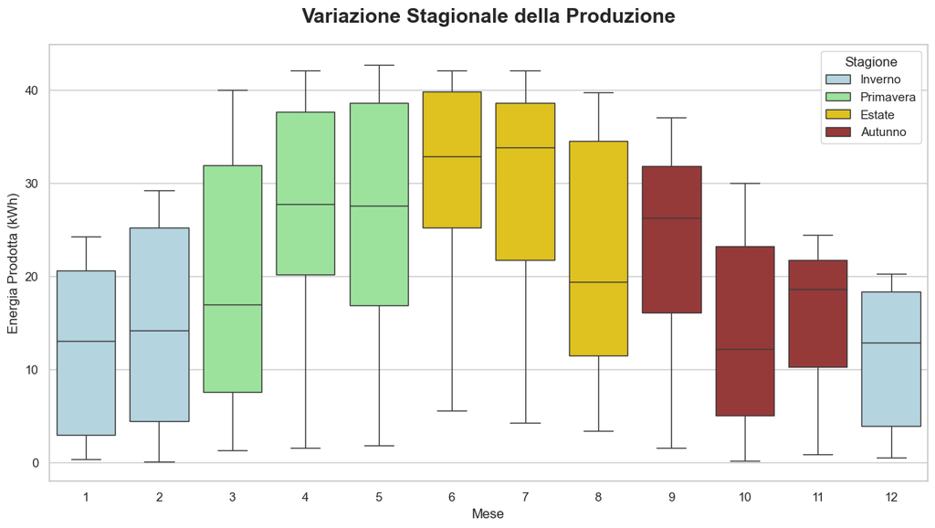

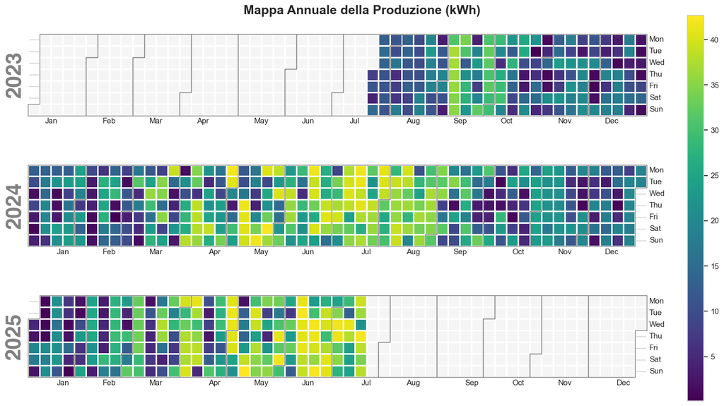

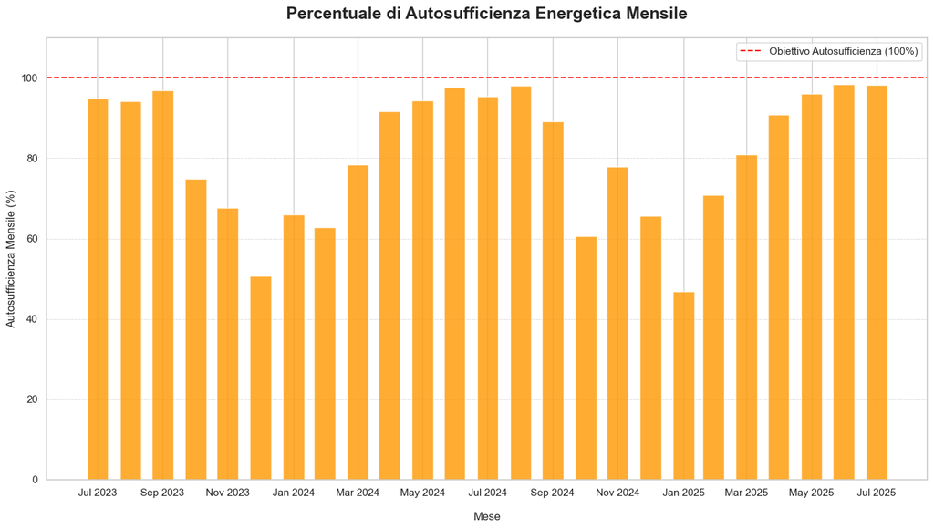

# Approfondimento: l'Impatto della Temperatura sull'Efficienza

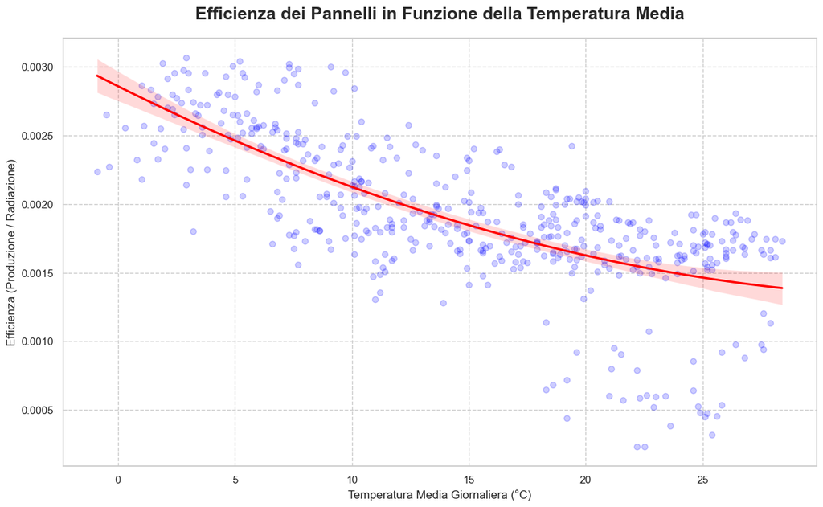

### Coefficiente di correlazione di Spearman: -0.739

# 2- Impatto delle Abitudini di Consumo

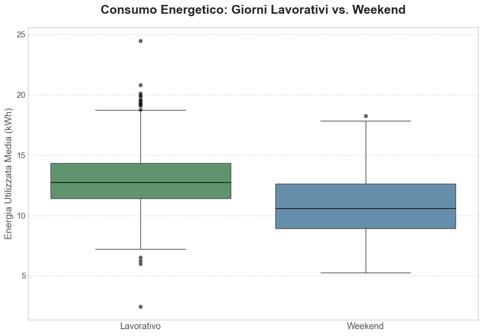

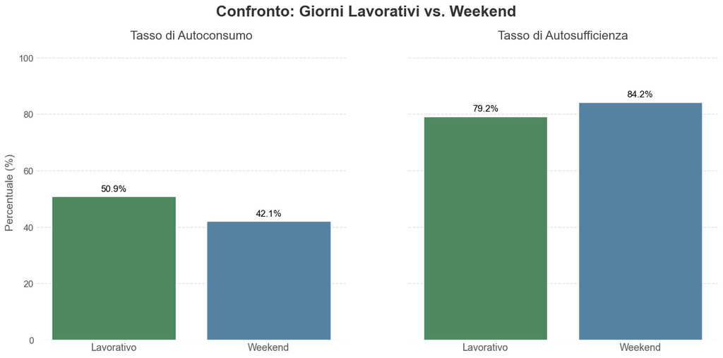

# 3- Analisi Economica

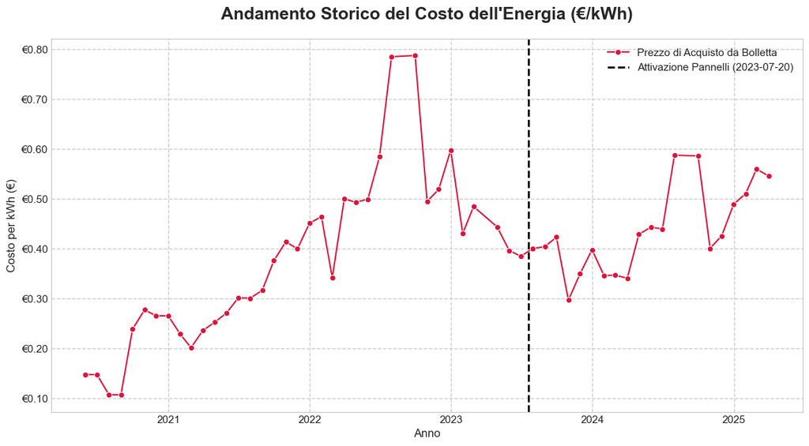

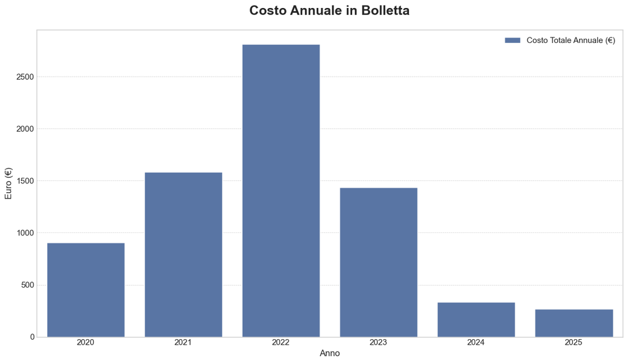

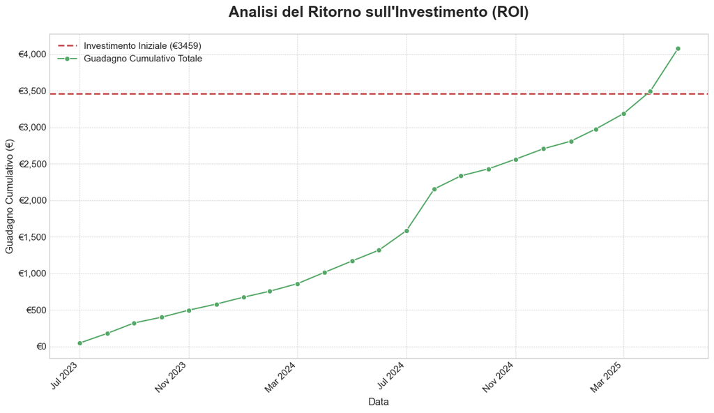

# Conclusioni: Sintesi dei Risultati

### **Risposta 1: Stagionalità**

La produzione fotovoltaica è fortemente stagionale. L'analisi ci permette di prevedere i periodi di massima e minima generazione.

Inoltre, l'efficienza è inversamente correlata alla temperatura.

### **Risposta 2: In Sintesi**

Sebbene la produzione sia simile, nei giorni lavorativi si registra un tasso di autoconsumo più elevato, massimizzando il valore dell'energia prodotta.

Nei weekend, al contrario, si ottiene un'autosufficienza maggiore, ma con un minore tasso di autoconsumo a causa dell'energia in eccesso che viene rivenduta.

### **Risposta 3: Impatto Economico**

L'impianto installato ha superato il punto di pareggio finanziario, portando un ritorno economico positivo. L'investimento iniziale non solo è stato ripagato, ma il sistema sta ora generando un guadagno continuo grazie all'autoconsumo e alla vendita dell'energia in eccesso.